# Analysis of Natural Catastrophies on Life and Economy from: (1950 - November 2011)

Whitchurch Muthumani

2/17/2020

### Synopsis

Natural Catastrophies such as Storms, Tornadoes Fires, etc cause major disruptions in the areas where they occur.

This document presents and analysis of the effects of such catastrophies which have been labeled as “Events” for the purpose of analysis.

It seeks to answer the following questions:

1. Across the United States, which types of events are most harmful with respect to population health?
2. Across the United States, which types of events have the greatest economic consequences?

The document is broken into the following sections: 1. Data Processing 2. Results

### 1. Data Processing

Data processing is broken down into 2 steps: 1.1 Loading the data 1.2 Cleaning up the data

#### 1.1 Loading the data

```r
library(dplyr)
```

```r
library(ggplot2)
library(colorspace)
library(gridExtra)
#====== Begin by loading the data=====
datatoanalyze <- read.csv("repdata-data-StormData.csv.bz2", header = TRUE, sep = ",")
```

#### Code breakdown:

- *Line 1- 4: load required packages.*
- *Line 5: unzips the bz2 file and reads contents into the datatoanalyze dataframe.*

```r
#== Analyze the structure of the dataset
str(datatoanalyze)
```

```
## 'data.frame':    902297 obs. of  37 variables:
##  $ STATE__   : num  1 1 1 1 1 1 1 1 1 1 ...
##  $ BGN_DATE  : Factor w/ 16335 levels "1/1/1966 0:00:00",..: 6523 6523 4242 11116 2224 2224 2260 383 3980 3980 ...
##  $ BGN_TIME  : Factor w/ 3608 levels "00:00:00 AM",..: 272 287 2705 1683 2584 3186 242 1683 3186 3186 ...
##  $ TIME_ZONE : Factor w/ 22 levels "ADT","AKS","AST",..: 7 7 7 7 7 7 7 7 7 7 ...
##  $ COUNTY    : num  97 3 57 89 43 77 9 123 125 57 ...
##  $ COUNTYNAME: Factor w/ 29601 levels "","5NM E OF MACKINAC BRIDGE TO PRESQUE ISLE LT MI",..: 13513 1873 4598 10592 4372 10094 1973 23873 24418 4598 ...
##  $ STATE     : Factor w/ 72 levels "AK","AL","AM",..: 2 2 2 2 2 2 2 2 2 2 ...
##  $ EVTYPE    : Factor w/ 985 levels "   HIGH SURF ADVISORY",..: 834 834 834 834 834 834 834 834 834 834 ...
##  $ BGN_RANGE : num  0 0 0 0 0 0 0 0 0 0 ...
##  $ BGN_AZI   : Factor w/ 35 levels "","  N"," NW",..: 1 1 1 1 1 1 1 1 1 1 ...
##  $ BGN_LOCATI: Factor w/ 54429 levels ""," Christiansburg",..: 1 1 1 1 1 1 1 1 1 1 ...
##  $ END_DATE  : Factor w/ 6663 levels "","1/1/1993 0:00:00",..: 1 1 1 1 1 1 1 1 1 1 ...
##  $ END_TIME  : Factor w/ 3647 levels ""," 0900CST",..: 1 1 1 1 1 1 1 1 1 1 ...
##  $ COUNTY_END: num  0 0 0 0 0 0 0 0 0 0 ...
```

[output cut: 23 more lines]

```r
datatoanalyze$EVTYPE <- as.character(datatoanalyze$EVTYPE)
length(unique(datatoanalyze$EVTYPE))
```

```
## [1] 985
```

The basic structure of the dataframe has been printed out for analysis, It has the following:

- 902297 rows and 37 columns
- **EVTYPE:** The name of the “Event” (Natural Catastrophe)
- **FATALATIES:** Number of deaths due to “Event”
- **INJURIES:** Number of injuries due to “Event”
- **PROPDMG:** property damages cost due to “Event”
- **CROPDMG:** crops damages cost due to “Event”
- **PROPDMGEXP:** Property damage in powers of 10
- **CROPDMGEXP:** Crop damage in powers of 10

#### 1.2 Cleaning up the data

#### Part 1: Removing the aliases for the event names, and associating them with the NOAA list of approvent events

We begin by viewing the table of all events:

```r
#sort(table(datatoanalyze$EVTYPE))
unique(datatoanalyze$EVTYPE)
```

```
##   [1] "TORNADO"                        "TSTM WIND"
##   [3] "HAIL"                           "FREEZING RAIN"
##   [5] "SNOW"                           "ICE STORM/FLASH FLOOD"
##   [7] "SNOW/ICE"                       "WINTER STORM"
##   [9] "HURRICANE OPAL/HIGH WINDS"      "THUNDERSTORM WINDS"
##  [11] "RECORD COLD"                    "HURRICANE ERIN"
##  [13] "HURRICANE OPAL"                 "HEAVY RAIN"
##  [15] "LIGHTNING"                      "THUNDERSTORM WIND"
##  [17] "DENSE FOG"                      "RIP CURRENT"
##  [19] "THUNDERSTORM WINS"              "FLASH FLOOD"
##  [21] "FLASH FLOODING"                 "HIGH WINDS"
##  [23] "FUNNEL CLOUD"                   "TORNADO F0"
##  [25] "THUNDERSTORM WINDS LIGHTNING"   "THUNDERSTORM WINDS/HAIL"
##  [27] "HEAT"                           "WIND"
##  [29] "LIGHTING"                       "HEAVY RAINS"
```

[output cut: 478 more lines]

We see there are many events that are not part of the approved list of events from the NOAA database.  
We proceed to clean up the data by combining the **major ones** into valid event types.

*Note: I’ve done most, but not all of the events , there has been a reduction 985 to 165*

```r
#=== Combine tose non-NOAA events into NOAA event types.
datatoanalyze[grep("(^TSTM)",datatoanalyze$EVTYPE, ignore.case = T),"EVTYPE"] <- "Thunderstorm Wind"
datatoanalyze[grep("(^Thunder|thunderstorm)",datatoanalyze$EVTYPE, ignore.case = T),"EVTYPE"] <- "Thunderstorm Wind"
datatoanalyze[grep("(^Thu)",datatoanalyze$EVTYPE, ignore.case = T),"EVTYPE"] <- "Thunderstorm Wind"
datatoanalyze[grep("^hurr",datatoanalyze$EVTYPE, ignore.case = T),"EVTYPE"] <- "Hurricane/Typhoon"
datatoanalyze[grep("^typ",datatoanalyze$EVTYPE, ignore.case = T),"EVTYPE"] <- "Hurricane/Typhoon"
datatoanalyze[grep("(^heavy snow)",datatoanalyze$EVTYPE, ignore.case = T),"EVTYPE"] <- "Heavy Snow"
datatoanalyze[grep("(^heavy rain)",datatoanalyze$EVTYPE, ignore.case = T),"EVTYPE"] <- "Heavy Rain"
datatoanalyze[grep("(^hail|hail)",datatoanalyze$EVTYPE, ignore.case = T),"EVTYPE"] <- "Hail"
datatoanalyze[grep("(^high wind)",datatoanalyze$EVTYPE, ignore.case = T),"EVTYPE"] <- "High Wind"
datatoanalyze[grep("(^tornado|^TORNDAO)",datatoanalyze$EVTYPE, ignore.case = T),"EVTYPE"] <- "Tornado"
datatoanalyze[grep("(^rip)",datatoanalyze$EVTYPE, ignore.case = T),"EVTYPE"] <- "Rip Current"
datatoanalyze[grep("(^wild)",datatoanalyze$EVTYPE, ignore.case = T),"EVTYPE"] <- "Wildfire"
datatoanalyze[grep("(^summary)",datatoanalyze$EVTYPE, ignore.case = T),"EVTYPE"] <- "Summary"
datatoanalyze[grep("(^lightn)",datatoanalyze$EVTYPE, ignore.case = T),"EVTYPE"] <- "Lightning"
datatoanalyze[grep("(^winter weather)",datatoanalyze$EVTYPE, ignore.case = T),"EVTYPE"] <- "Winter Weather"
datatoanalyze[grep("(^volcanic)",datatoanalyze$EVTYPE, ignore.case = T),"EVTYPE"] <- "Volcanic Ash"
datatoanalyze[grep("(^winter stor|^snow)",datatoanalyze$EVTYPE, ignore.case = T),"EVTYPE"] <- "Winter Storm"
datatoanalyze[grep("(flood)",datatoanalyze$EVTYPE, ignore.case = T),"EVTYPE"] <- "Flood"
datatoanalyze[grep("^water",datatoanalyze$EVTYPE, ignore.case = T),"EVTYPE"] <- "Waterspout"
datatoanalyze[grep("mix$",datatoanalyze$EVTYPE, ignore.case = T),"EVTYPE"] <- "Sleet"
datatoanalyze[grep("wind",datatoanalyze$EVTYPE, ignore.case = T),"EVTYPE"] <- "Strong Wind"
datatoanalyze[grep("Ice|Icy",datatoanalyze$EVTYPE, ignore.case = T),"EVTYPE"] <- "Ice Storm"
datatoanalyze[grep("heat|warm|hot",datatoanalyze$EVTYPE, ignore.case = T),"EVTYPE"] <- "Heat"
datatoanalyze[grep("coast",datatoanalyze$EVTYPE, ignore.case = T),"EVTYPE"] <- "Coastal Flood"
datatoanalyze[grep("cold",datatoanalyze$EVTYPE, ignore.case = T),"EVTYPE"] <- "Extreme Cold/Wind Chill"
datatoanalyze[grep("tropical s",datatoanalyze$EVTYPE, ignore.case = T),"EVTYPE"] <- "Tropical Storm"
datatoanalyze[grep("tropical d",datatoanalyze$EVTYPE, ignore.case = T),"EVTYPE"] <- "Tropical Depression"
datatoanalyze[grep("snow",datatoanalyze$EVTYPE, ignore.case = T),"EVTYPE"] <- "Heavy Snow"
datatoanalyze[grep("rain|slide",datatoanalyze$EVTYPE, ignore.case = T),"EVTYPE"] <- "Heavy Rain"
datatoanalyze[grep("og$",datatoanalyze$EVTYPE, ignore.case = T),"EVTYPE"] <- "Dense Fog"
datatoanalyze[grep("smoke",datatoanalyze$EVTYPE, ignore.case = T),"EVTYPE"] <- "Dense Smoke"
datatoanalyze[grep("freez",datatoanalyze$EVTYPE, ignore.case = T),"EVTYPE"] <- "Frost/Freeze"
datatoanalyze[grep("surf",datatoanalyze$EVTYPE, ignore.case = T),"EVTYPE"] <- "High Surf"
datatoanalyze[grep("surge",datatoanalyze$EVTYPE, ignore.case = T),"EVTYPE"] <- "Storm Surge/Tide"
datatoanalyze[grep("funnel",datatoanalyze$EVTYPE, ignore.case = T),"EVTYPE"] <- "Funnel Cloud"
datatoanalyze[grep("fld",datatoanalyze$EVTYPE, ignore.case = T),"EVTYPE"] <- "Flood"
datatoanalyze[grep("blizzard",datatoanalyze$EVTYPE, ignore.case = T),"EVTYPE"] <- "Blizzard"
datatoanalyze[grep("wind$|WND$",datatoanalyze$EVTYPE, ignore.case = T),"EVTYPE"] <- "Strong Wind"
datatoanalyze[grep("HYPERTHERMIA/EXPOSURE|hypothermia|RECORD LOW|RECORD COOL|RECORD PRECIPITATION",datatoanalyze$EVTYPE, ignore.case = T),"EVTYPE"] <- "Extreme Cold/Wind Chill"
datatoanalyze[grep("DRY SPELL|DRY WEATHER|RECORD HIGH TEMPERATURE|RECORD HIGH|HIGH TEMPERATURE RECORD|RECORD DRYNESS|Record dry month|Temperature record|Record temperature|Record temperatures",datatoanalyze$EVTYPE, ignore.case = T),"EVTYPE"] <- "Excessive Heat"
datatoanalyze[grep("\\?",datatoanalyze$EVTYPE, ignore.case = T),"EVTYPE"] <- "Other"
```

We now look at the newly cleaned up set of events:

```r
#=== Newly reduced list of events
#sort(table(datatoanalyze$EVTYPE))
unique(datatoanalyze$EVTYPE)
```

```
##   [1] "Tornado"                    "Strong Wind"
##   [3] "Hail"                       "Heavy Rain"
##   [5] "Winter Storm"               "Flood"
##   [7] "Hurricane/Typhoon"          "Extreme Cold/Wind Chill"
##   [9] "Lightning"                  "Dense Fog"
##  [11] "Rip Current"                "Funnel Cloud"
##  [13] "Heat"                       "LIGHTING"
##  [15] "WALL CLOUD"                 "Waterspout"
##  [17] "Blizzard"                   "Heavy Snow"
##  [19] "Frost/Freeze"               "HIGH TIDES"
##  [21] "Excessive Heat"             "Ice Storm"
##  [23] "AVALANCHE"                  "MARINE MISHAP"
##  [25] "HIGH SEAS"                  "SEVERE TURBULENCE"
##  [27] "DUST STORM"                 "APACHE COUNTY"
##  [29] "SLEET"                      "DUST DEVIL"
```

[output cut: 67 more lines]

#### Part 2: Processing the Property and Crop Damages, by changing the EXP to their respective exponents.and then multiplying the exponents with the values to get the total values

First we prepare the data that needs to be cleaned, converting factors to characters

```r
datatoanalyze$PROPDMGEXP <- as.character(datatoanalyze$PROPDMGEXP)
listofPROPDMGEXP <- unique(datatoanalyze$PROPDMGEXP)

datatoanalyze$CROPDMGEXP <- as.character(datatoanalyze$CROPDMGEXP)
listofCROPDMGEXP <- unique(datatoanalyze$CROPDMGEXP)
```

Then we create the respective multipliers for both the Crop and Property

```r
#=== Creating Crop damage multiplier.
datatoanalyze$CROPDMGMULTIPLIER[datatoanalyze$CROPDMGEXP == ""] <- 0
datatoanalyze$CROPDMGMULTIPLIER[datatoanalyze$CROPDMGEXP == "M"] <- 1000000
datatoanalyze$CROPDMGMULTIPLIER[datatoanalyze$CROPDMGEXP == "K"] <- 1000
datatoanalyze$CROPDMGMULTIPLIER[datatoanalyze$CROPDMGEXP == "m"] <- 1000000
datatoanalyze$CROPDMGMULTIPLIER[datatoanalyze$CROPDMGEXP == "B"] <- 1000000000
datatoanalyze$CROPDMGMULTIPLIER[datatoanalyze$CROPDMGEXP == "?"] <- 0
datatoanalyze$CROPDMGMULTIPLIER[datatoanalyze$CROPDMGEXP == "0"] <- 1
datatoanalyze$CROPDMGMULTIPLIER[datatoanalyze$CROPDMGEXP == "k"] <- 1000
datatoanalyze$CROPDMGMULTIPLIER[datatoanalyze$CROPDMGEXP == "2"] <- 100

#== creating Property Damage Multiplier
datatoanalyze$PROPDMGMULTIPLIER[datatoanalyze$PROPDMGEXP ==  "K"    ]  <-    1000
datatoanalyze$PROPDMGMULTIPLIER[datatoanalyze$PROPDMGEXP == "M"     ]   <-  1000000
datatoanalyze$PROPDMGMULTIPLIER[datatoanalyze$PROPDMGEXP == ""      ]   <-  0
datatoanalyze$PROPDMGMULTIPLIER[datatoanalyze$PROPDMGEXP == "B"     ]   <-  1000000000
datatoanalyze$PROPDMGMULTIPLIER[datatoanalyze$PROPDMGEXP == "m"     ]   <-  1000000
datatoanalyze$PROPDMGMULTIPLIER[datatoanalyze$PROPDMGEXP == "+"     ]   <-  0
datatoanalyze$PROPDMGMULTIPLIER[datatoanalyze$PROPDMGEXP == "0"     ]   <-  1
datatoanalyze$PROPDMGMULTIPLIER[datatoanalyze$PROPDMGEXP == "5"     ]   <-  100000
datatoanalyze$PROPDMGMULTIPLIER[datatoanalyze$PROPDMGEXP == "6"     ]   <-  1000000
datatoanalyze$PROPDMGMULTIPLIER[datatoanalyze$PROPDMGEXP == "?"     ]   <-  0
datatoanalyze$PROPDMGMULTIPLIER[datatoanalyze$PROPDMGEXP == "4"     ]   <-  10000
datatoanalyze$PROPDMGMULTIPLIER[datatoanalyze$PROPDMGEXP == "2"     ]   <-  100
datatoanalyze$PROPDMGMULTIPLIER[datatoanalyze$PROPDMGEXP == "3"     ]   <-  1000
datatoanalyze$PROPDMGMULTIPLIER[datatoanalyze$PROPDMGEXP == "h"     ]   <-  100
datatoanalyze$PROPDMGMULTIPLIER[datatoanalyze$PROPDMGEXP == "7"     ]   <-  10000000
datatoanalyze$PROPDMGMULTIPLIER[datatoanalyze$PROPDMGEXP == "H"     ]   <-  100
datatoanalyze$PROPDMGMULTIPLIER[datatoanalyze$PROPDMGEXP == "-"     ]   <-  0
datatoanalyze$PROPDMGMULTIPLIER[datatoanalyze$PROPDMGEXP =="1"     ]   <-  10
datatoanalyze$PROPDMGMULTIPLIER[datatoanalyze$PROPDMGEXP =="8"     ]   <-  100000000
```

We then generate the Crop damage and Property damage amounts by : multiplying the numeric Crop/Property damage numbers against their respective Crop/Property damage multipliers:

The mathermatic code for that is given below:

```r
datatoanalyze$PROPERTYDMGVAL <- datatoanalyze$PROPDMG * datatoanalyze$PROPDMGMULTIPLIER
datatoanalyze$CROPDMGVAL <- datatoanalyze$CROPDMG * datatoanalyze$CROPDMGMULTIPLIER
```

### Results

We now proceed to use the data from Data Processing to answer the following questions:

**Across the United States, which types of events are most harmful with respect to population health?**

```r
# == Plotting out the information for health toll
#== Check for NAs. in Injusties and Fatalities. There are none.
sum(as.integer(is.na(datatoanalyze$FATALITIES)))
```

```
## [1] 0
```

```r
sum(as.integer(is.na(datatoanalyze$INJURIES)))
```

```
## [1] 0
```

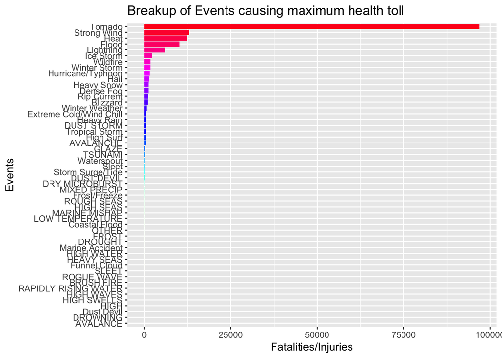

```r
#=== we will combine the injuries and Fatalities into a common variable called healthToll
datatoanalyze$healthtoll <- datatoanalyze[,"FATALITIES"] + datatoanalyze[,"INJURIES"]

#== we wil look only at subset of rows with healthtoll(FATALITIES+INJURIES) with greather than 0 occurences
OnlyDataWithhealthToll <- datatoanalyze[datatoanalyze$healthtoll > 0,]




##=== We now group the events and summarize

groupbyEVTYPE <- group_by(OnlyDataWithhealthToll,EVTYPE)
groupbyEVTYPE <- summarise_at(groupbyEVTYPE, .vars = c("healthtoll"),sum)%>%arrange(desc(healthtoll))



##==== Results:
# Log scale
ggplot(data = groupbyEVTYPE,aes(x=reorder(EVTYPE, (healthtoll)),y = healthtoll))+geom_bar(stat = "identity",fill = rainbow(n=length(groupbyEVTYPE$EVTYPE)))+coord_flip()+xlab("Events") + ylab("Fatalities/Injuries")+ggtitle("Breakup of Events causing maximum health toll")
```

#### Inference:

**Across the United States, which types of events have the greatest economic consequences?**

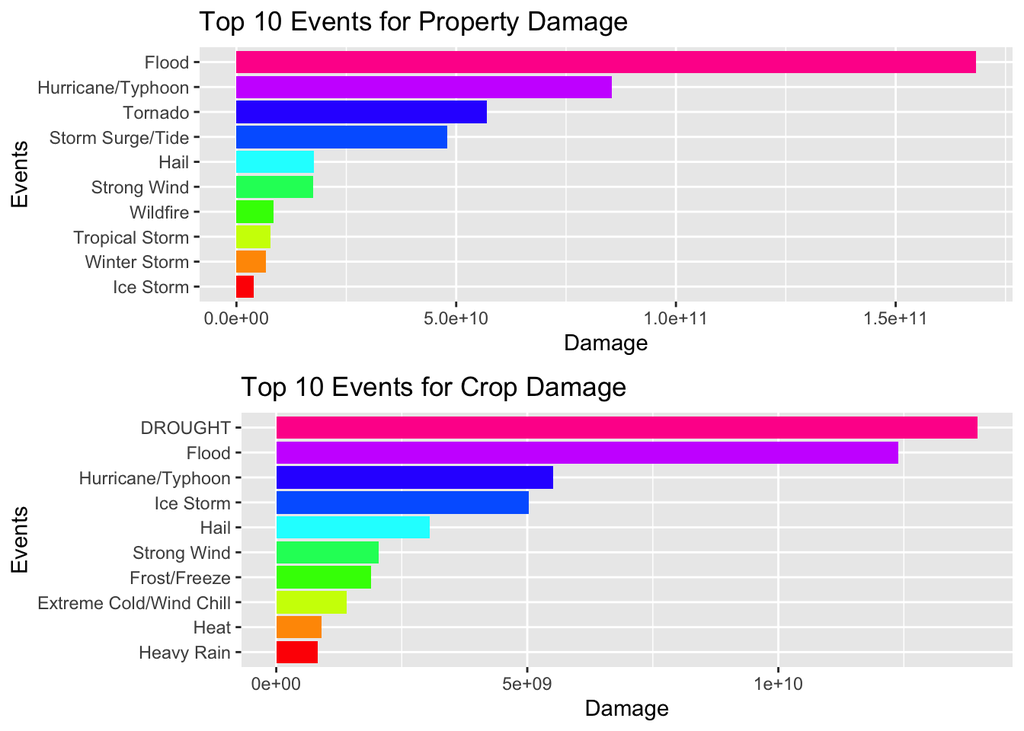

```r
OnlyDataWithPropertydmg <- datatoanalyze[datatoanalyze$PROPDMG > 0,]
groupbyEVTYPE1 <- group_by(OnlyDataWithPropertydmg,EVTYPE)
groupbyEVTYPE1 <- summarise_at(groupbyEVTYPE1, .vars = c("PROPERTYDMGVAL"), sum)%>%arrange(desc(PROPERTYDMGVAL))

OnlyDataWithCropdmg <- datatoanalyze[datatoanalyze$CROPDMG > 0,]
groupbyEVTYPE2 <- group_by(OnlyDataWithCropdmg,EVTYPE)
groupbyEVTYPE2 <- summarise_at(groupbyEVTYPE2, .vars = c("CROPDMGVAL"), sum)%>%arrange(desc(CROPDMGVAL))


plot1 <- ggplot(data = groupbyEVTYPE1[1:10,],aes(x=reorder(EVTYPE, (PROPERTYDMGVAL)),y = PROPERTYDMGVAL))+geom_bar(stat = "identity",fill = rainbow(n=length(groupbyEVTYPE1[1:10,]$EVTYPE)))+coord_flip()+xlab("Events") + ylab("Damage")+ggtitle("Top 10 Events for Property Damage")
plot2 <- ggplot(data = groupbyEVTYPE2[1:10,],aes(x=reorder(EVTYPE, (CROPDMGVAL)),y = CROPDMGVAL))+geom_bar(stat = "identity",fill = rainbow(n=length(groupbyEVTYPE2[1:10,]$EVTYPE)))+coord_flip()+xlab("Events") + ylab("Damage")+ggtitle("Top 10 Events for Crop Damage")

grid.arrange(plot1,plot2, nrow = 2)
```

#### Code breakdown:

- *Line 1: look only at subset of rows with atleast Property damage of 1 or more.*
- *Line 2: group data by their Events.*
- *Line 3: summarise total Property damage for each Event type and sort from larges to smallest.*
- *Line 4: look only at subset of rows with atleast Crop damage of 1 or more.*
- *Line 5: group data by their Events.*
- *Line 6: summarise total Crop damage for each Event type and sort from larges to smallest.*
- *Line 7: generatate the plot for property damage.*
- *Line 8: generate the plot for crop damage.*
- *Line 9: print both plots in the same picture.*

#### Inference:

# Final Conclusion:

- Droughts are expensive in terms of Crop damage.
- Floods and typhoons are expensive in terms of Property damage.

### Tornados are expensive in terms of Property damage (featuring at number3) as well as highly dangerous for human lives. Prioritize reducing the damaging effects of Tornados